# M3T2_FirstContact

Ale F. Benages

3/30/2021

# Library

```r
library(caret, ggplot2)
library(ggridges)
library(plyr)
library(skimr) # to get a fast overview of all the variables. Fast&Dirty EDA
#library(tictoc)
library(mlbench)
library(gbm)
library(C50)
set.seed(9982)
```

# Load CSV

```r
path_to_file <- "//home/ale/Dropbox/UBIQUM/3.DAwithR/Task2:Classification.in.R/SurveyData/CompleteResponses.csv"

ComResp <- read.csv(path_to_file)

str(ComResp) # with srt() we can see the structure of the dataframe
```

```
## 'data.frame':    9898 obs. of  7 variables:
##  $ salary : num  119807 106880 78021 63690 50874 ...
##  $ age    : int  45 63 23 51 20 56 24 62 29 41 ...
##  $ elevel : int  0 1 0 3 3 3 4 3 4 1 ...
##  $ car    : int  14 11 15 6 14 14 8 3 17 5 ...
##  $ zipcode: int  4 6 2 5 4 3 5 0 0 4 ...
##  $ credit : num  442038 45007 48795 40889 352951 ...
##  $ brand  : int  0 1 0 1 0 1 1 1 0 1 ...
```

```r
# head(ComResp) # with head we get a similar output but with the classic dataframe structure
```

# EDA

**Numerical Variables**  
* Salary  
* Age  
* Credit **Ordinal Categorical Variables**  
* elevel **Nominal Categorical Variables**  
* Zipcode  
* Car  
* Brand

## Datatypes

Datatypes from the categorical (ordinal or nominal) variables are incorrect: **elevel, car, zipcode and brand** datatypes should be changed to factor.

```r
# change the datatype to factor
ComResp[, 'elevel'] <- as.factor(ComResp[, 'elevel'])
ComResp[, 'car'] <- as.factor(ComResp[, 'car'])
ComResp[, 'zipcode'] <- as.factor(ComResp[, 'zipcode'])
ComResp[, 'brand'] <- as.factor(ComResp[, 'brand'])

str(ComResp)
```

```
## 'data.frame':    9898 obs. of  7 variables:
##  $ salary : num  119807 106880 78021 63690 50874 ...
##  $ age    : int  45 63 23 51 20 56 24 62 29 41 ...
##  $ elevel : Factor w/ 5 levels "0","1","2","3",..: 1 2 1 4 4 4 5 4 5 2 ...
##  $ car    : Factor w/ 20 levels "1","2","3","4",..: 14 11 15 6 14 14 8 3 17 5 ...
##  $ zipcode: Factor w/ 9 levels "0","1","2","3",..: 5 7 3 6 5 4 6 1 1 5 ...
##  $ credit : num  442038 45007 48795 40889 352951 ...
##  $ brand  : Factor w/ 2 levels "0","1": 1 2 1 2 1 2 2 2 1 2 ...
```

### add labels

also we can add the corresponding labels to each categorical variable

```r
# list of labels of elevel
ed_level_labels = c("Less than High School Degree", "High School Degree", "Some College","4-Year College Degree",
             "Master's, Doctoral or Professional Degree")
# create a new column 'elevelLabeled', copy of elevel with values remaped
ComResp$elevelLabeled <- mapvalues(ComResp$elevel, from=c(0:4), to=ed_level_labels)

cars_labels = c("BMW", "Buick", "Cadillac", "Chevrolet", "Chrysler", "Dodge", "Ford", "Honda", "Hyundai", "Jeep", "Kia", "Lincoln", "Mazda", "Mercedes Benz", "Mitsubishi", "Nissan", "Ram", "Subaru", "Toyota", "None of the above")
ComResp$carLabeled <- mapvalues(ComResp$car, from=c(0:19), to=cars_labels)
zipcode_labels = c("New England", "Mid-Atlantic", "East North Central", "West North Central", "South Atlantic", "East South Central", "West South Central", "Mountain", "Pacific")
ComResp$zipcodeLabeled <- mapvalues(ComResp$zipcode, from=c(0:8), to=zipcode_labels)

brands_labels = c("Acer", "Sony")
ComResp$brandLabeled <- mapvalues(ComResp$brand, from=c(0:1), to=brands_labels)
```

the Skim function gives us a great overview of the dataset

```r
skim(ComResp)
```

Data summary

| Name | ComResp |
| --- | --- |
| Number of rows | 9898 |
| Number of columns | 11 |
| _______________________ |  |
| Column type frequency: |  |
| factor | 8 |
| numeric | 3 |
| ________________________ |  |
| Group variables | None |

**Variable type: factor**

| skim_variable | n_missing | complete_rate | ordered | n_unique | top_counts |
| --- | --- | --- | --- | --- | --- |
| elevel | 0 | 1 | FALSE | 5 | 0: 2052, 2: 1983, 4: 1968, 1: 1948 |
| car | 0 | 1 | FALSE | 20 | 15: 542, 18: 524, 8: 511, 2: 509 |
| zipcode | 0 | 1 | FALSE | 9 | 6: 1155, 8: 1135, 2: 1112, 5: 1108 |
| brand | 0 | 1 | FALSE | 2 | 1: 6154, 0: 3744 |
| elevelLabeled | 0 | 1 | FALSE | 5 | Les: 2052, Som: 1983, Mas: 1968, Hig: 1948 |
| carLabeled | 0 | 1 | FALSE | 20 | Nis: 542, Toy: 524, Hyu: 511, Cad: 509 |
| zipcodeLabeled | 0 | 1 | FALSE | 9 | Wes: 1155, Pac: 1135, Eas: 1112, Eas: 1108 |
| brandLabeled | 0 | 1 | FALSE | 2 | Son: 6154, Ace: 3744 |

**Variable type: numeric**

| skim_variable | n_missing | complete_rate | mean | sd | p0 | p25 | p50 | p75 | p100 | hist |
| --- | --- | --- | --- | --- | --- | --- | --- | --- | --- | --- |
| salary | 0 | 1 | 84870.86 | 37712.34 | 20000 | 52082.11 | 84949.74 | 117162.0 | 150000 | ▇▇▇▇▇ |
| age | 0 | 1 | 49.78 | 17.60 | 20 | 35.00 | 50.00 | 65.0 | 80 | ▇▇▇▇▇ |
| credit | 0 | 1 | 249175.97 | 145211.57 | 0 | 120806.81 | 250607.15 | 374639.7 | 500000 | ▇▇▇▇▇ |

## Missing values and NA ?

- No missing values

## Plots of each variables.

### 1. Salary

Survey Questions and Response Key  
1) What is your yearly salary, not including bonuses?. Respondents enter numeric value

- **This is a numerical variable.**

```r
summary(ComResp$salary)
```

```
##    Min. 1st Qu.  Median    Mean 3rd Qu.    Max.
##   20000   52082   84950   84871  117162  150000
```

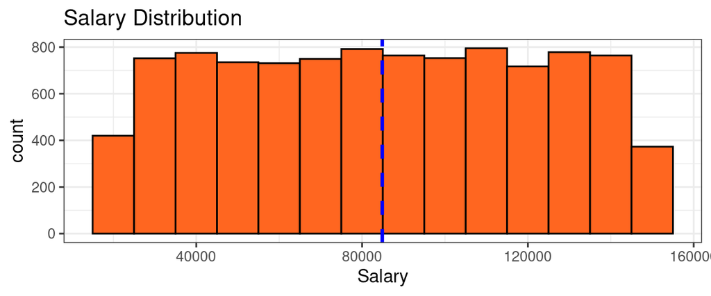

```r
ggplot( ComResp, aes(x=salary)) + theme_bw()+
  geom_histogram(color = 'black', fill = '#FF6620', binwidth = 10000)+
  labs(title = "Salary Distribution", x="Salary") +
  geom_vline(aes(xintercept=mean(salary)), color="blue", linetype="dashed", size=1)  # adds the mean
```

### 2. Age

Survey Questions and Response Key  
2) What is your age?. Respondents enter numeric value

- ** This is a Numerical Variable**

```r
summary(ComResp$age)
```

```
##    Min. 1st Qu.  Median    Mean 3rd Qu.    Max.
##   20.00   35.00   50.00   49.78   65.00   80.00
```

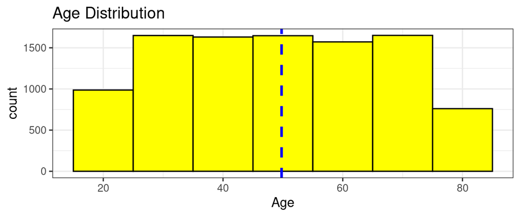

```r
ggplot( ComResp, aes(x=age)) + theme_bw()+
  geom_histogram(color = 'black', fill = 'yellow', binwidth = 10)+
  labs(title = "Age Distribution", x="Age") +
  geom_vline(aes(xintercept=mean(age)), color="blue", linetype="dashed", size=1)  # adds the mean
```

### 3. elevel - Education Level

3. What is the highest level of education you have obtained?. Respondents select from the following 5 choices:  
   Value : Description  
   0 : Less than High School Degree  
   1 : High School Degree  
   2 : Some College  
   3 : 4-Year College Degree  
   4 : Master’s, Doctoral or Professional Degree
- **This is a categorical ordinal variable**

```r
# print the head just to verify everything is correct
head(ComResp)
```

```
##      salary age elevel car zipcode    credit brand                elevelLabeled
## 1 119806.54  45      0  14       4 442037.71     0 Less than High School Degree
## 2 106880.48  63      1  11       6  45007.18     1           High School Degree
## 3  78020.75  23      0  15       2  48795.32     0 Less than High School Degree
## 4  63689.94  51      3   6       5  40888.88     1        4-Year College Degree
## 5  50873.62  20      3  14       4 352951.50     0        4-Year College Degree
## 6 130812.74  56      3  14       3 135943.02     1        4-Year College Degree
##   carLabeled     zipcodeLabeled brandLabeled
## 1 Mitsubishi     South Atlantic         Acer
## 2    Lincoln West South Central         Sony
## 3     Nissan East North Central         Acer
## 4       Ford East South Central         Sony
## 5 Mitsubishi     South Atlantic         Acer
## 6 Mitsubishi West North Central         Sony
```

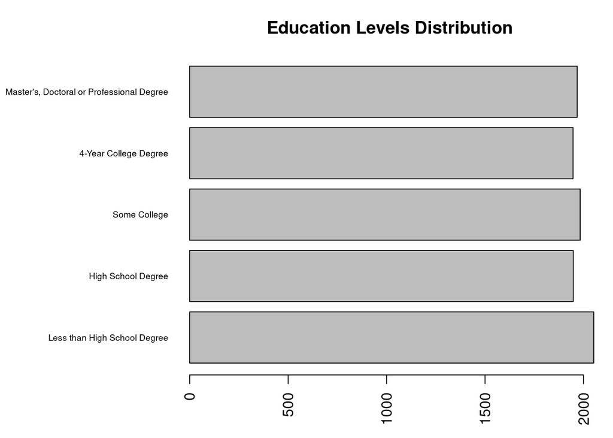

```r
# magins of the plot
# mar: A numerical vector of the form c(bottom, left, top, right) which gives
# the number of lines of margin to be specified on the four sides of the plot.
# The default is c(5, 4, 4, 2) + 0.1.
par(mar=c(3.5,10.5,3,1)+0.1)

counts <- table(ComResp$elevelLabeled)

# finally a Simple Horizontal Bar Plot with Added Labels
barplot(counts, main="Education Levels Distribution", horiz=TRUE, names.arg=ed_level_labels, cex.names=0.6, las=2)
```

> In general the education level of customers is very homogeneous.

### 4. Car

4. What is the make of your primary car?. Respondents select from the following 20 choices: Value : Description 1 : BMW  
   2 : Buick  
   3 : Cadillac  
   4 : Chevrolet  
   5 : Chrysler  
   6 : Dodge  
   7 : Ford  
   8 : Honda  
   9 : Hyundai  
   10 : Jeep  
   11 : Kia  
   12 : Lincoln  
   13 : Mazda  
   14 : Mercedes Benz  
   15 : Mitsubishi  
   16 : Nissan  
   17 : Ram  
   18 : Subaru  
   19 : Toyota  
   20 : None of the above
- **this is a Nominal categorical variable**

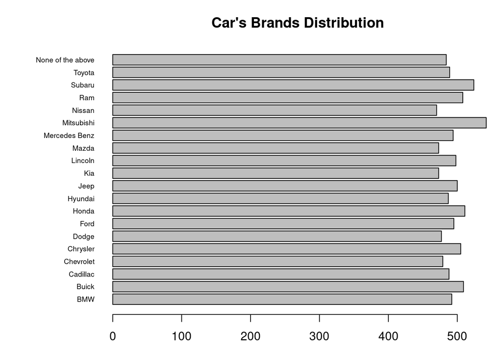

```r
# Simple Horizontal Bar Plot with Added Labels
par(mar=c(3,7.5,3,1)+0.1)
# mar: A numerical vector of the form c(bottom, left, top, right) which gives
# the number of lines of margin to be specified on the four sides of the plot.
# The default is c(5, 4, 4, 2) + 0.1.

Car_counts <- table(ComResp$carLabeled)

barplot(Car_counts, main="Car's Brands Distribution", horiz=TRUE, names.arg=cars_labels, cex.names=0.6, las=1,)
```

> There is no preffered car’s brand. the chocices are very homogeneous.

### 5. zipcode

5. What is your zip code?. Respondents enter zip code, which is captured as 1 of the following 9 regions in the U.S.  
   Value : Region  
   0 : New England  
   1 : Mid-Atlantic  
   2 : East North Central  
   3 : West North Central  
   4 : South Atlantic  
   5 : East South Central  
   6 : West South Central  
   7 : Mountain  
   8 : Pacific
- **This is a categorical Nominal variable**

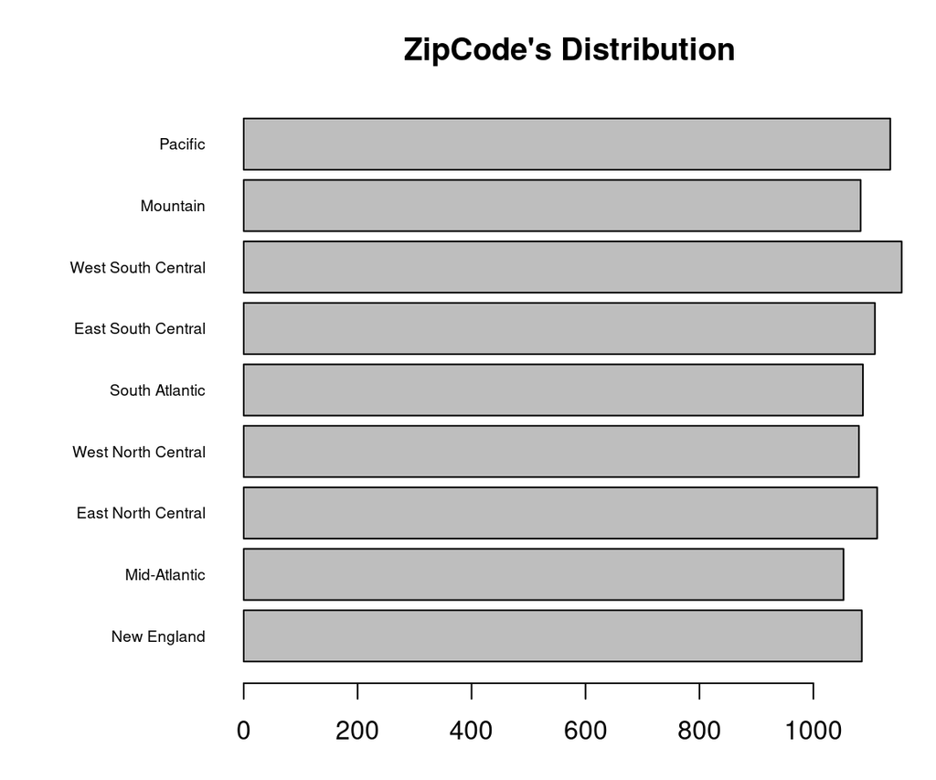

```r
# Simple Horizontal Bar Plot with Added Labels
par(mar=c(3,7.5,3,1)+0.1)
# mar: A numerical vector of the form c(bottom, left, top, right) which gives
# the number of lines of margin to be specified on the four sides of the plot.
# The default is c(5, 4, 4, 2) + 0.1.

zipcode_counts <- table(ComResp$zipcodeLabeled)

barplot(zipcode_counts, main="ZipCode's Distribution", horiz=TRUE, names.arg=zipcode_labels, cex.names=0.6, las=1,)
```

### 6. Credit

6. What amount of credit is available to you?. Respondents enter numeric value.
- **Quantitative variable**

```r
summary(ComResp$credit)
```

```
##    Min. 1st Qu.  Median    Mean 3rd Qu.    Max.
##       0  120807  250607  249176  374640  500000
```

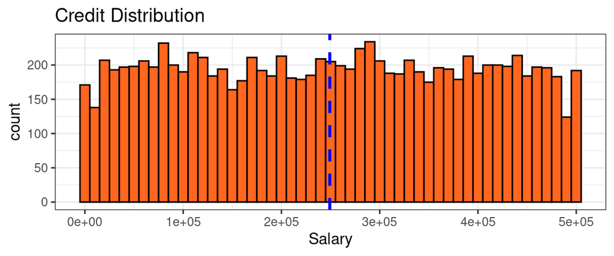

```r
ggplot( ComResp, aes(x=credit)) + theme_bw()+
  geom_histogram(color = 'black', fill = '#FF6620', binwidth = 10000)+
  labs(title = "Credit Distribution", x="Salary") +
  geom_vline(aes(xintercept=mean(credit)), color="blue", linetype="dashed", size=1)  # this line adds the mean
```

### 7. brand

7. Which brand of computers do you prefer?. Respondents select from the following 2 choices:  
   Value : Description  
   0 : Acer  
   1 : Sony

> this is our **Target variable.**

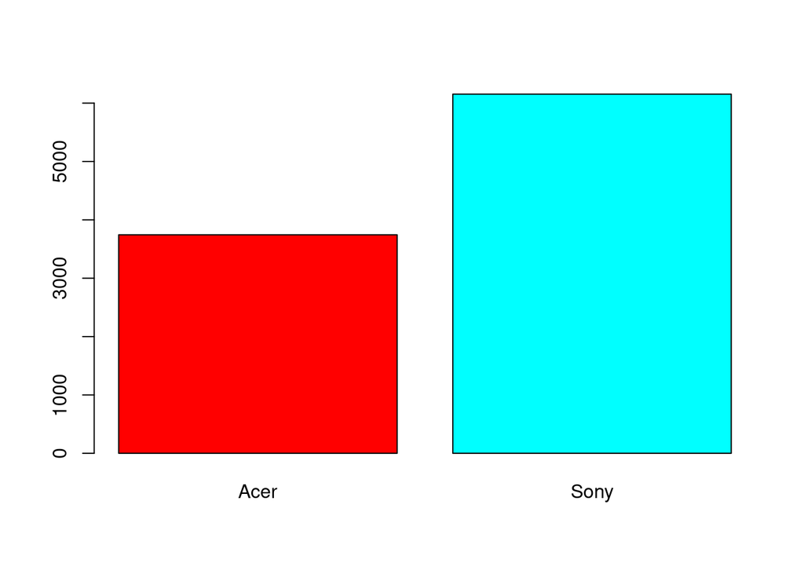

```r
brand_table <- table(ComResp$brand)

barplot(brand_table,
        col = rainbow(2),
        names.arg = c("Acer", "Sony"))
```

## Normalization

The formula for a min-max normalization is:
$$(X – min(X))/(max(X) – min(X))$$
For each value of a variable, we simply find how far that value is from the minimum value, then divide by the range. To implement this in R, we can define a simple function and then use lapply to apply that function to whichever columns in the dataset:

```r
#define Min-Max normalization function
min_max_norm <- function(x) {
  (x - min(x)) / (max(x) - min(x))
  }
```

```r
#apply Min-Max normalization to the numerical variables
ComResp_norm <- as.data.frame(lapply(ComResp[c('salary','age','credit')], min_max_norm))
#print structure
str(ComResp_norm)
```

```
## 'data.frame':    9898 obs. of  3 variables:
##  $ salary: num  0.768 0.668 0.446 0.336 0.237 ...
##  $ age   : num  0.417 0.717 0.05 0.517 0 ...
##  $ credit: num  0.8841 0.09 0.0976 0.0818 0.7059 ...
```

```r
#summary
summary(ComResp_norm)
```

```
##      salary            age             credit
##  Min.   :0.0000   Min.   :0.0000   Min.   :0.0000
##  1st Qu.:0.2468   1st Qu.:0.2500   1st Qu.:0.2416
##  Median :0.4996   Median :0.5000   Median :0.5012
##  Mean   :0.4990   Mean   :0.4963   Mean   :0.4984
##  3rd Qu.:0.7474   3rd Qu.:0.7500   3rd Qu.:0.7493
##  Max.   :1.0000   Max.   :1.0000   Max.   :1.0000
```

The result looks great, all the numerical variables from 0 to 1, and also they are very symmetric. 1Q is close to 0.25, Mean ~ 0.5 and 3Q ~ 0.75.  
But notice that all the rest of the variables were dropped out. They must be added manually.

```r
ComResp_norm$elevel <- ComResp$elevel
ComResp_norm$car <- ComResp$car
ComResp_norm$zipcode <- ComResp$zipcode
ComResp_norm$brand <- ComResp$brand

#ComResp_norm$elevelLabeled <- ComResp$elevelLabeled
#ComResp_norm$carLabeled <- ComResp$carLabeled
#ComResp_norm$zipcodeLabeled <- ComResp$zipcodeLabeled
#ComResp_norm$brandLabeled <- ComResp$brandLabeled

str(ComResp_norm)
```

```
## 'data.frame':    9898 obs. of  7 variables:
##  $ salary : num  0.768 0.668 0.446 0.336 0.237 ...
##  $ age    : num  0.417 0.717 0.05 0.517 0 ...
##  $ credit : num  0.8841 0.09 0.0976 0.0818 0.7059 ...
##  $ elevel : Factor w/ 5 levels "0","1","2","3",..: 1 2 1 4 4 4 5 4 5 2 ...
##  $ car    : Factor w/ 20 levels "1","2","3","4",..: 14 11 15 6 14 14 8 3 17 5 ...
##  $ zipcode: Factor w/ 9 levels "0","1","2","3",..: 5 7 3 6 5 4 6 1 1 5 ...
##  $ brand  : Factor w/ 2 levels "0","1": 1 2 1 2 1 2 2 2 1 2 ...
```

# Train the Models

## Train/Test Split

```r
# define an 75%/25% train/test split of the dataset
inTraining <- caret::createDataPartition(ComResp_norm$brand, p = .75, list = FALSE)
training <- ComResp_norm[inTraining,]
testing <- ComResp_norm[-inTraining,]
```

## Models

> Models training commented, to avoid execution.

## Load the Models

as I avoided the execution of the models, but previously saved them, I load them from them memory

```r
gbmFit1 <- readRDS("./Models/gbmFit1.rds")
gbmFit2 <- readRDS ('./Models/gbmFit2.rds')
rfFit1 <- readRDS ('./Models/rfmFit1.rds')
rfFit2 <- readRDS ('./Models/rfmFit2.rds')
rfFit3 <- readRDS ('./Models/rfmFit3.rds')
c50Fit <- readRDS ('./Models/c50Fit.rds')
```

## Predictions on the Complete Survey - (Ground Truth)

```r
print('GBM1')
```

```
## [1] "GBM1"
```

```r
brand_prediction_GBM <- predict(gbmFit1, testing)   # does the prediction predict(model, testData)
postResample(brand_prediction_GBM, testing$brand)  # After making the predictions using the
```

```
##  Accuracy     Kappa
## 0.9264349 0.8452281
```

```r
print('GBM2')
```

```
## [1] "GBM2"
```

```r
brand_prediction_GBM <- predict(gbmFit2, testing)   # does the prediction predict(model, testData)
postResample(brand_prediction_GBM, testing$brand)  # After making the predictions using the
```

```
##  Accuracy     Kappa
## 0.9288601 0.8505161
```

```r
#brand_prediction_GBM <- predict(gbmFit2, testing_reduced)   # does the prediction predict(model, testData)
#postResample(brand_prediction_GBM, testing_reduced$brandLabeled)  # After making the predictions using the test set use postResample() to assess the metrics of the new predictions compared to the Ground Truth

print('RF1')
```

```
## [1] "RF1"
```

```r
brand_prediction_RF1 <- predict(rfFit1, testing)
postResample(brand_prediction_RF1, testing$brand)
```

```
##  Accuracy     Kappa
## 0.9248181 0.8410371
```

```r
#brand_prediction_RF1 <- predict(rfFit1, testing_reduced)
#postResample(brand_prediction_RF1, testing_reduced$brandLabeled)

print('RF2')
```

```
## [1] "RF2"
```

```r
brand_prediction_RF2 <- predict(rfFit2, testing)
postResample(brand_prediction_RF2, testing$brand)
```

```
##  Accuracy     Kappa
## 0.9296686 0.8509828
```

```r
#brand_prediction_RF2 <- predict(rfFit2, testing_reduced)
#postResample(brand_prediction_RF2, testing_reduced$brandLabeled)


print('RF3')
```

```
## [1] "RF3"
```

```r
brand_prediction_RF3 <- predict(rfFit3, testing)
postResample(brand_prediction_RF3, testing$brand)
```

```
##  Accuracy     Kappa
## 0.9292643 0.8504070
```

```r
#brand_prediction_RF3 <- predict(rfFit3, testing_reduced)
#postResample(brand_prediction_RF3, testing_reduced$brandLabeled)

print('C5.0')
```

```
## [1] "C5.0"
```

```r
brand_prediction_c50 <- predict(c50Fit, testing)
postResample(brand_prediction_c50, testing$brand)
```

```
##  Accuracy     Kappa
## 0.8439774 0.6681770
```

```r
#brand_prediction_c50 <- predict(c50Fit, testing_reduced)
#postResample(brand_prediction_c50, testing_reduced$brandLabeled)
```

### Select a model

Based on the results of the predictions, the bests models are:

> “RF2” > rfFit2 > Accuracy: 0.9296686  
> “RF3” > rfFit3 > Accuracy: 0.9292643  
> “GBM2” > gbmFit2 > Accuracy: 0.9288601

### Remove redundant data

So we can remove the rest of the variables to improve performance and reduce computational costs.

```r
ComResp_norm_reduced <- ComResp_norm #creates a copy of the DF
ComResp_norm_reduced$elevel <- NULL  #removes the elevel variable
ComResp_norm_reduced$car <- NULL
ComResp_norm_reduced$zipcode <- NULL
ComResp_norm_reduced$brand <- NULL  #as we have the brandLabeled, this is useless
```

In the training I forgot to add the labels to the brand, and it’s useful…

```r
brands_labels = c("Acer", "Sony")
ComResp_norm_reduced$brandLabeled <- mapvalues(ComResp_norm$brand, from=c(0:1), to=brands_labels)
```

```r
str(ComResp_norm_reduced)
```

```
## 'data.frame':    9898 obs. of  4 variables:
##  $ salary      : num  0.768 0.668 0.446 0.336 0.237 ...
##  $ age         : num  0.417 0.717 0.05 0.517 0 ...
##  $ credit      : num  0.8841 0.09 0.0976 0.0818 0.7059 ...
##  $ brandLabeled: Factor w/ 2 levels "Acer","Sony": 1 2 1 2 1 2 2 2 1 2 ...
```

just to check if everything still nice… train again the RF2 with the reduced dataset

```r
# train/test split of the dataset
inTraining_reduced <- createDataPartition(ComResp_norm_reduced$brandLabeled, p = .75, list = FALSE)
training_reduced <- ComResp_norm_reduced[inTraining_reduced,]
testing_reduced <- ComResp_norm_reduced[-inTraining_reduced,]
```

Commented this part of the code to avoid execution. But the model is saved in memory.

## Load the Models

as I avoided the execution of the models, but previously saved them, I load them from them memory

```r
rfFit2_reduced <- readRDS("./Models/rfFit2_reduced.rds")
```

```r
predictions_reduced <- predict(rfFit2_reduced, testing_reduced)
summary(predictions_reduced)
```

```
## Acer Sony
##  942 1532
```

```r
confusionMatrix(predictions_reduced, testing_reduced$brandLabeled)
```

```
## Confusion Matrix and Statistics
##
##           Reference
## Prediction Acer Sony
##       Acer  919   23
##       Sony   17 1515
##
##                Accuracy : 0.9838
##                  95% CI : (0.978, 0.9884)
##     No Information Rate : 0.6217
##     P-Value [Acc > NIR] : <2e-16
##
##                   Kappa : 0.9657
##
##  Mcnemar's Test P-Value : 0.4292
##
##             Sensitivity : 0.9818
##             Specificity : 0.9850
##          Pos Pred Value : 0.9756
##          Neg Pred Value : 0.9889
##              Prevalence : 0.3783
##          Detection Rate : 0.3715
##    Detection Prevalence : 0.3808
##       Balanced Accuracy : 0.9834
##
##        'Positive' Class : Acer
##
```

# Incomlpete Survey

## Load CSV - Incomplete

```r
path_to_file <- "//home/ale/Dropbox/UBIQUM/3.DAwithR/Task2:Classification.in.R/SurveyData/SurveyIncomplete.csv"

IncompleteResp <- read.csv(path_to_file)

str(IncompleteResp) # with srt() we can see the structure of the dataframe
```

```
## 'data.frame':    5000 obs. of  7 variables:
##  $ salary : num  150000 82524 115647 141443 149211 ...
##  $ age    : int  76 51 34 22 56 26 64 50 26 46 ...
##  $ elevel : int  1 1 0 3 0 4 3 3 2 3 ...
##  $ car    : int  3 8 10 18 5 12 1 9 3 18 ...
##  $ zipcode: int  3 3 2 2 3 1 2 0 4 6 ...
##  $ credit : num  377980 141658 360980 282736 215667 ...
##  $ brand  : int  1 0 1 1 1 1 1 1 1 0 ...
```

## Drop Unnecesary data

```r
IncompleteResp_reduced <- IncompleteResp #creates a copy of the DF
IncompleteResp_reduced$elevel <- NULL
IncompleteResp_reduced$car <- NULL
IncompleteResp_reduced$zipcode <- NULL
IncompleteResp_reduced$brand <- NULL

str(IncompleteResp_reduced) #take a look to the reduced DF
```

```
## 'data.frame':    5000 obs. of  3 variables:
##  $ salary: num  150000 82524 115647 141443 149211 ...
##  $ age   : int  76 51 34 22 56 26 64 50 26 46 ...
##  $ credit: num  377980 141658 360980 282736 215667 ...
```

## EDA

```r
skim(IncompleteResp_reduced)
```

Data summary

| Name | IncompleteResp_reduced |
| --- | --- |
| Number of rows | 5000 |
| Number of columns | 3 |
| _______________________ |  |
| Column type frequency: |  |
| numeric | 3 |
| ________________________ |  |
| Group variables | None |

**Variable type: numeric**

| skim_variable | n_missing | complete_rate | mean | sd | p0 | p25 | p50 | p75 | p100 | hist |
| --- | --- | --- | --- | --- | --- | --- | --- | --- | --- | --- |
| salary | 0 | 1 | 85793.81 | 37800.01 | 20000 | 52589.96 | 86220.72 | 118535.2 | 150000 | ▇▇▇▇▇ |
| age | 0 | 1 | 49.94 | 17.67 | 20 | 35.00 | 50.00 | 65.0 | 80 | ▇▇▇▇▇ |
| credit | 0 | 1 | 249546.21 | 145859.26 | 0 | 122310.71 | 250973.69 | 375652.7 | 500000 | ▇▇▇▇▇ |

- no missing values.
- from a fast and simple comparative of the Quantiles ans mean, Salady and Age from the complete and incomplete survey are very similar!. >> would be nice to plot two histograms overlayed, comparing the distributions.

### Normalization

```r
#apply Min-Max normalization to the numerical variables
IncompleteResp_reduced_norm <- as.data.frame(lapply(IncompleteResp_reduced[c('salary','age','credit')], min_max_norm))
str(IncompleteResp_reduced_norm)
```

```
## 'data.frame':    5000 obs. of  3 variables:
##  $ salary: num  1 0.481 0.736 0.934 0.994 ...
##  $ age   : num  0.9333 0.5167 0.2333 0.0333 0.6 ...
##  $ credit: num  0.756 0.283 0.722 0.565 0.431 ...
```

## Train/Test Split.

I this case I want to guess the brand choice, out target variable, from the *Incomplete Survey*. I don’t have this information, so it’s useless to do the train/test split. In this case the entire set is used to make predictions.

## Load the model

will load the saved copy of the model: **RF2_reduced**

```r
super_model <- readRDS("./Models/rfFit2_reduced.rds")
print(super_model)
```

```
## Random Forest
##
## 7424 samples
##    3 predictor
##    2 classes: 'Acer', 'Sony'
##
## No pre-processing
## Resampling: Cross-Validated (10 fold, repeated 5 times)
## Summary of sample sizes: 6682, 6682, 6682, 6682, 6681, 6681, ...
## Resampling results across tuning parameters:
##
##   mtry  Accuracy   Kappa
##   1     0.9206092  0.8314534
##   2     0.9167307  0.8231428
##
## Accuracy was used to select the optimal model using the largest value.
## The final value used for the model was mtry = 1.
```

## Guessing!

I’m using the RF2 to guess the brand choice of the incomplete survey.

```r
guess <- predict(super_model, IncompleteResp_reduced_norm)
summary(guess)
```

```
## Acer Sony
## 1903 3097
```

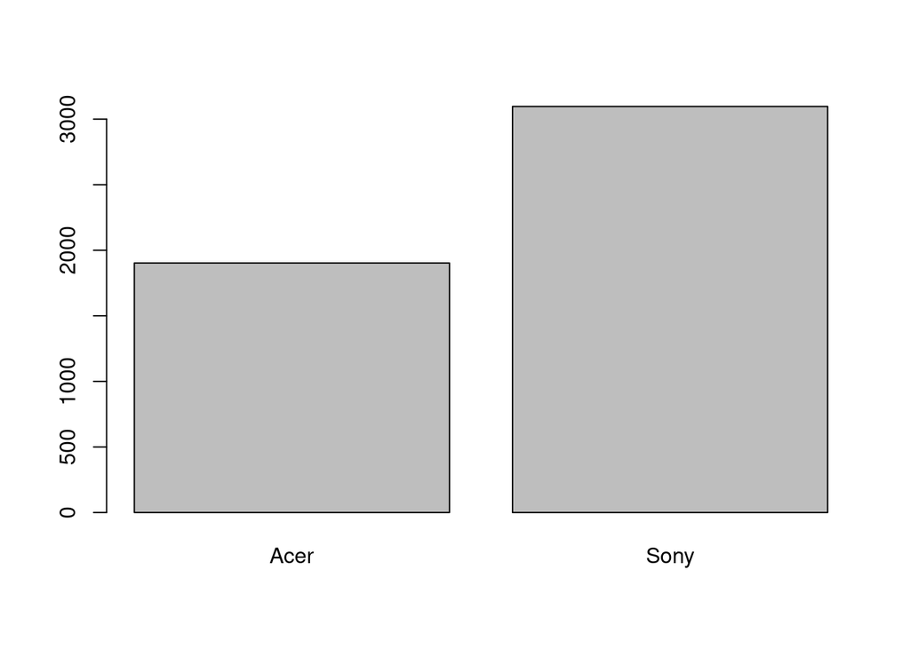

```r
plot(guess)
```

# Analysis

## Samples Analisis

A sample is just a part of a population. It is important to compare the distribution of samples in the survey.

### Salary

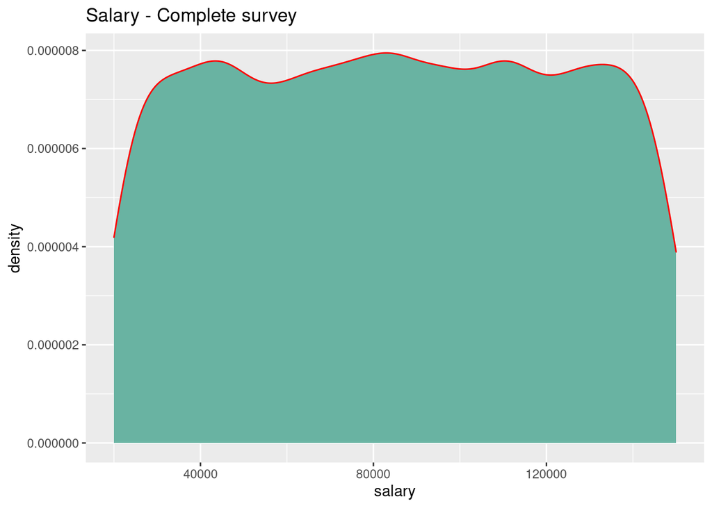

```r
options(scipen = 999) # removes scientific notation
ggplot(ComResp, aes(x=salary)) + geom_density(fill="#69b3a2", color="red") + ggtitle("Salary - Complete survey")
```

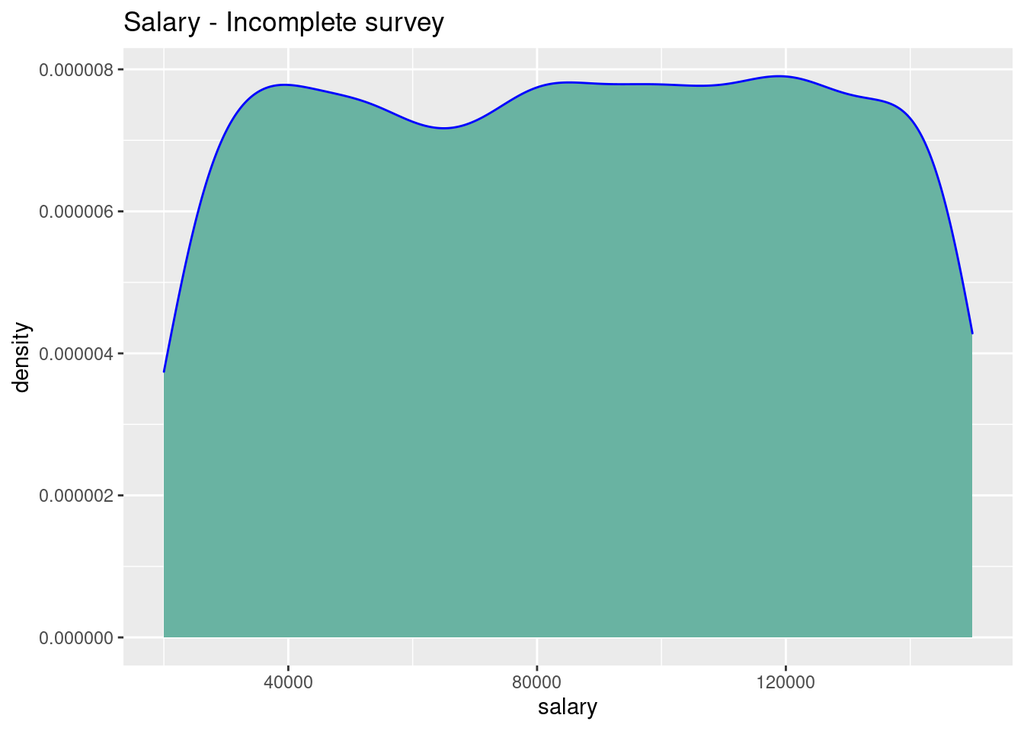

```r
ggplot(IncompleteResp, aes(x=salary)) + geom_density(fill="#69b3a2", color="blue") + ggtitle("Salary - Incomplete survey")
```

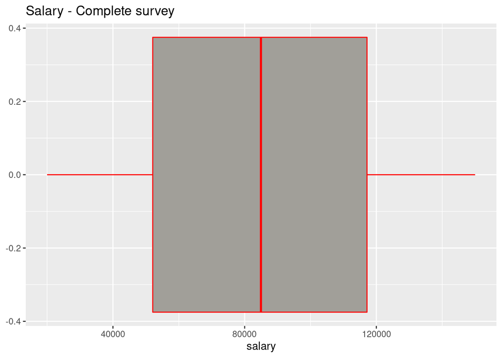

```r
ggplot(ComResp, aes(x=salary)) + geom_boxplot(fill="#A19F99", color="red")  + ggtitle("Salary - Complete survey")
```

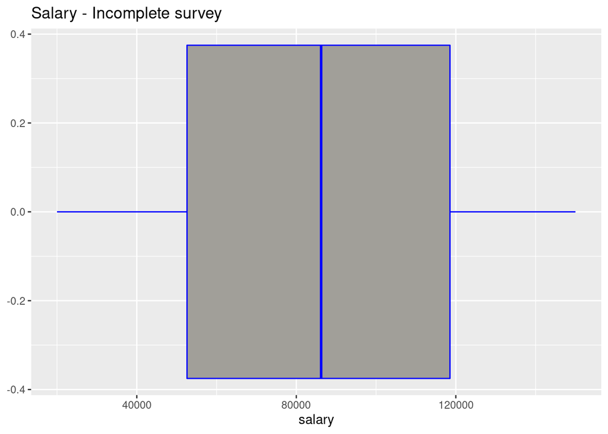

```r
ggplot(IncompleteResp, aes(x=salary)) + geom_boxplot(fill="#A19F99", color="blue") + ggtitle("Salary - Incomplete survey")
```

### Age

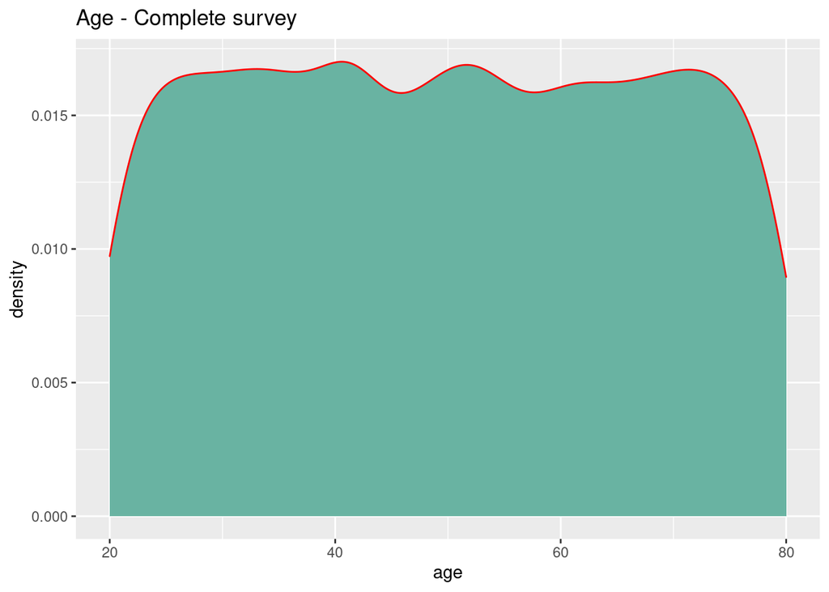

```r
options(scipen = 999) # removes scientific notation
ggplot(ComResp, aes(x=age)) +
    geom_density(fill="#69b3a2", color="red") +
  ggtitle("Age - Complete survey")
```

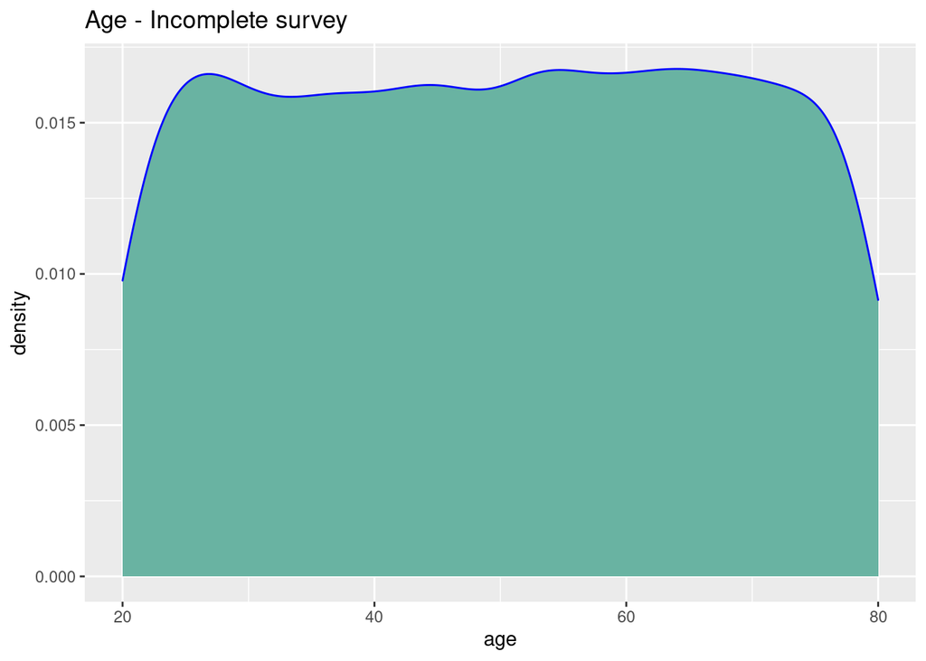

```r
ggplot(IncompleteResp, aes(x=age)) +
    geom_density(fill="#69b3a2", color="blue") +
  ggtitle("Age - Incomplete survey")
```

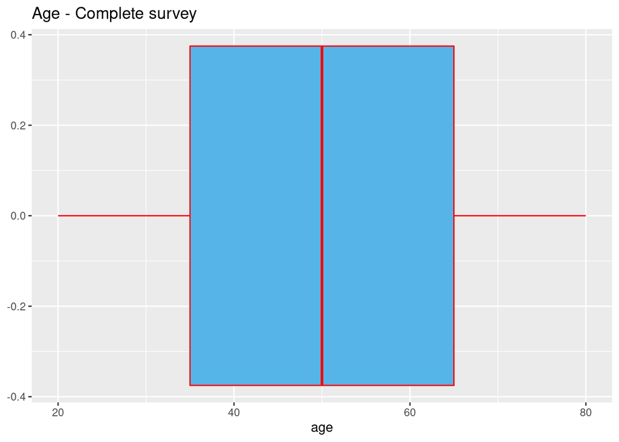

```r
ggplot(ComResp, aes(x=age)) + geom_boxplot(fill="#56B4E9", color="red") + ggtitle("Age - Complete survey")
```

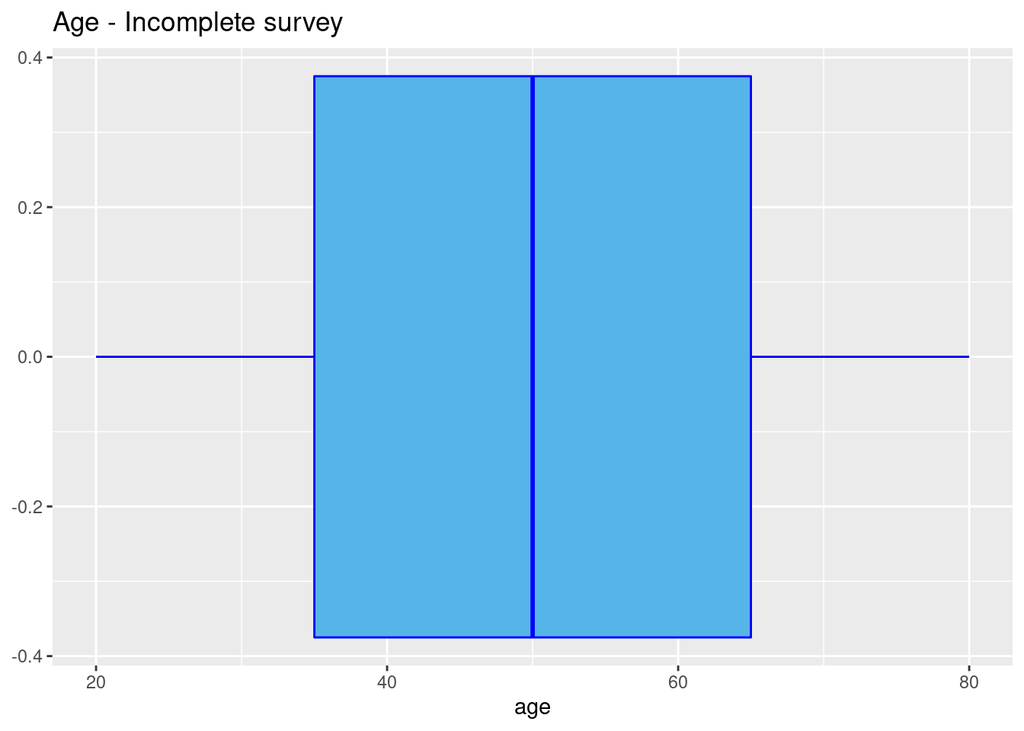

```r
ggplot(IncompleteResp, aes(x=age)) + geom_boxplot(fill="#56B4E9", color="Blue")  + ggtitle("Age - Incomplete survey")
```

### Credit

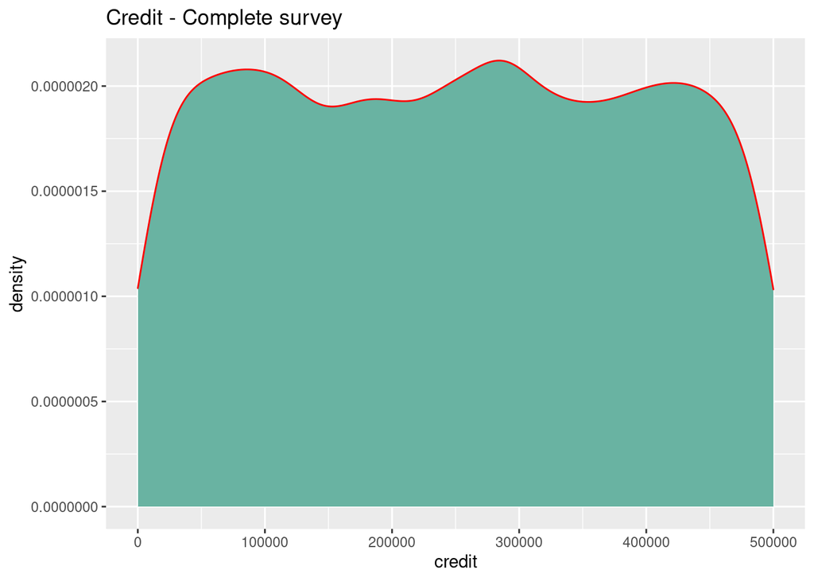

```r
options(scipen = 999) # removes scientific notation

ggplot(ComResp, aes(x=credit)) +
    geom_density(fill="#69b3a2", color="red") +
    ggtitle("Credit - Complete survey")
```

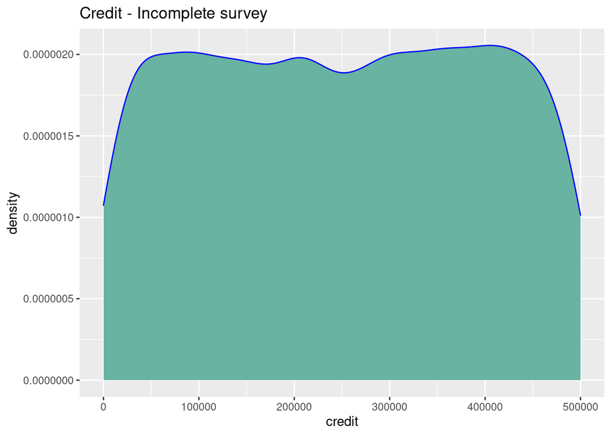

```r
ggplot(IncompleteResp, aes(x=credit)) +
    geom_density(fill="#69b3a2", color="blue") +
  ggtitle("Credit - Incomplete survey")
```

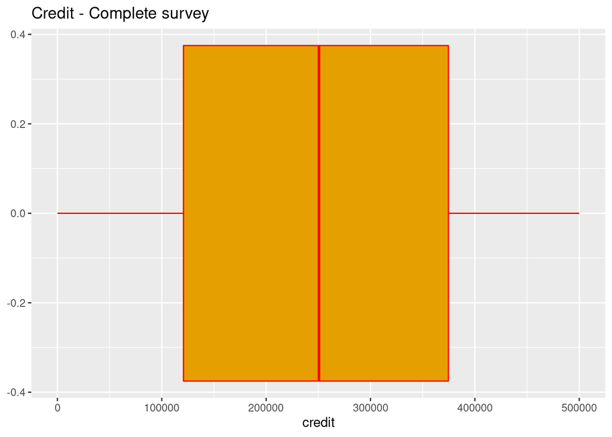

```r
ggplot(ComResp, aes(x=credit)) + geom_boxplot(fill="#E69F00", color="red")  + ggtitle("Credit - Complete survey")
```

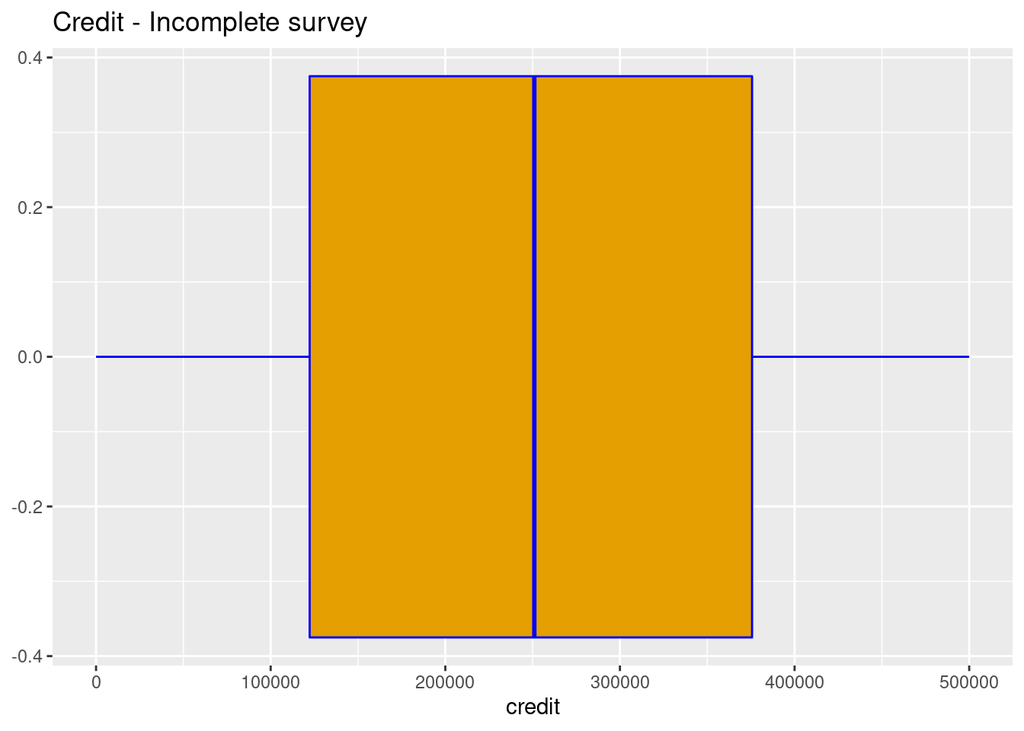

```r
ggplot(IncompleteResp, aes(x=credit)) + geom_boxplot(fill="#E69F00", color="blue") + ggtitle("Credit - Incomplete survey")
```

## Analysis of Proportions

- Guessed Proportion of Acer/Sony

```r
coso <- summary(guess)
guess_DF <- as.data.frame(coso)
#head(guess_DF)

# calculates the proportion of sony
proportion_guessed_sony = guess_DF[1,1]/guess_DF[2,1]
#proportion_guessed_sony

# acer = 1 - sony
proportion_guessed_acer = 1- proportion_guessed_sony
#proportion_guessed_acer

# add those values to a DF
vec <- c(proportion_guessed_acer, proportion_guessed_sony)
guess_DF$prop_guess <- vec


guess_DF$coso <- NULL  # elimino esta column temporal que no uso.
head(guess_DF)
```

```
##      prop_guess
## Acer  0.3855344
## Sony  0.6144656
```

- True Proportion of Acer/Sony

```r
coso2 <- summary(ComResp$brandLabeled)
trueProportion_DF <- as.data.frame(coso2)
#head(trueProportion_DF)
proportion_true_sony = trueProportion_DF[1,1]/trueProportion_DF[2,1]
#proportion_true_sony
proportion_true_acer = 1-proportion_true_sony
#proportion_true_acer

# add those values to a DF
vec <- c(proportion_true_acer, proportion_true_sony)
guess_DF$prop_true <- vec

allValues <- c(proportion_true_acer, proportion_guessed_acer, proportion_true_sony, proportion_guessed_sony)

head(guess_DF)
```

```
##      prop_guess prop_true
## Acer  0.3855344 0.3916152
## Sony  0.6144656 0.6083848
```

```r
proportion_true_sony/proportion_guessed_sony
```

```
## [1] 0.9901039
```

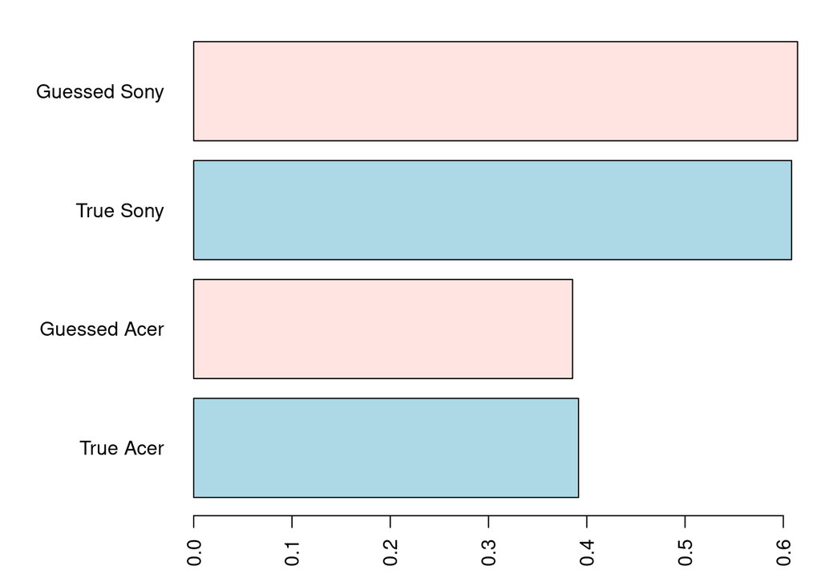

```r
# Increase margin size
par(mar=c(3,8,1,1)) #bottom, left, top, right respectively.

#plot_proportions <- barplot(allValues,
barplot(allValues,
  col = c("lightblue", "mistyrose", "lightblue", "mistyrose"),
  horiz = TRUE,
  names.arg = c("True Acer", "Guessed Acer", "True Sony", "Guessed Sony"),
  las = 2,
  xlab="Proportion")
```

```r
#plot_proportions
```

# DUDAS

- compare the distributions of the variables used to do the guesses with the ones used to train the model… are they similar?.
  - plot two histograms from different DF overlayed?
- if the population of both surveys are similar, then check if the proportion of the ground truth brand selection is similar with the proportion of the guessed selection. Do a graph coparing them.
- it’s not unsupervised learning. this is another thing. in this case we used labeled data to train a model. we got nice values of accuracy in our model and then we used this model to make guesses. nobody knows the correct answer, they are guesses based on the trained model, and it’s accuracy depends on the similarity of both populations. it’s like a model trained to predict fraud in online purchases, nobody knows in advance what the client will do. But we can train some predictive models with known past history, and based on some specific behaviors we can rise the alarm and be on guard. another example is the self driving cars: we can train a model to detect traffic lights, other cars, cyclists, etc. but when the model is loaded and the car is moving it’s impossible to confirm every thing the car sees… we must belive in his guesses.
- Kappa. if unbalanced data, take care of kappa.
- What If i have mixed input variables?. https://machinelearningmastery.com/feature-selection-with-real-and-categorical-data/
- how to bind two columns with different dimensions? fill the empty spaces withs NAN ?? pick 5000 measures randomly?
- Explain the importance of each feature used in the model and support it with quantitative evidence. What does it means?